# MST1.Rmd

2024-02-18

We will be analyzing a glass identification database.  
Attribute Information:  
1. Id number: 1 to 214  
2. RI: refractive index  
3. Na: Sodium (unit measurement: weight percent in corresponding oxide, as are attributes 4-10)  
4. Mg: Magnesium  
5. Al: Aluminum  
6. Si: Silicon  
7. K: Potassium  
8. Ca: Calcium  
9. Ba: Barium  
10. Fe: Iron  
11. Type of glass: (class attribute)  
– 1 building_windows_float_processed  
– 2 building_windows_non_float_processed  
– 3 vehicle_windows_float_processed  
– 4 vehicle_windows_non_float_processed (none in this database)  
– 5 containers  
– 6 tableware  
– 7 headlamps  
We will use attributes 2-10 to identify the type of glass.

```r
glass <- read.csv("C:/Users/ishita/Downloads/glass.csv",header = FALSE)
print(glass)
```

```
##      V1      V2    V3   V4   V5    V6   V7    V8   V9  V10 V11
## 1     1 1.52101 13.64 4.49 1.10 71.78 0.06  8.75 0.00 0.00   1
## 2     2 1.51761 13.89 3.60 1.36 72.73 0.48  7.83 0.00 0.00   1
## 3     3 1.51618 13.53 3.55 1.54 72.99 0.39  7.78 0.00 0.00   1
## 4     4 1.51766 13.21 3.69 1.29 72.61 0.57  8.22 0.00 0.00   1
## 5     5 1.51742 13.27 3.62 1.24 73.08 0.55  8.07 0.00 0.00   1
## 6     6 1.51596 12.79 3.61 1.62 72.97 0.64  8.07 0.00 0.26   1
## 7     7 1.51743 13.30 3.60 1.14 73.09 0.58  8.17 0.00 0.00   1
## 8     8 1.51756 13.15 3.61 1.05 73.24 0.57  8.24 0.00 0.00   1
## 9     9 1.51918 14.04 3.58 1.37 72.08 0.56  8.30 0.00 0.00   1
## 10   10 1.51755 13.00 3.60 1.36 72.99 0.57  8.40 0.00 0.11   1
## 11   11 1.51571 12.72 3.46 1.56 73.20 0.67  8.09 0.00 0.24   1
## 12   12 1.51763 12.80 3.66 1.27 73.01 0.60  8.56 0.00 0.00   1
## 13   13 1.51589 12.88 3.43 1.40 73.28 0.69  8.05 0.00 0.24   1
## 14   14 1.51748 12.86 3.56 1.27 73.21 0.54  8.38 0.00 0.17   1
```

[output cut: 200 more lines]

Now we will plot the multivariate data using a matrix scatterplot.

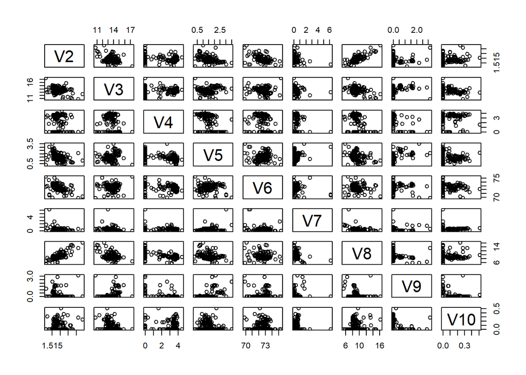

```r
pairs(glass[,2:10])
```

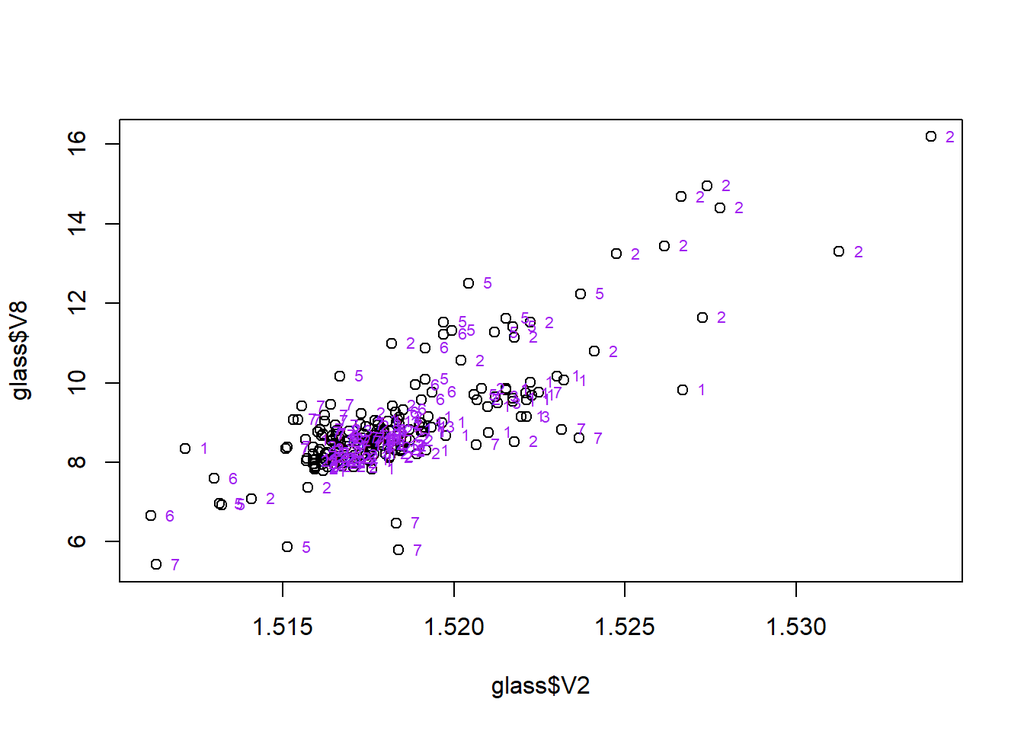

```r
plot(glass$V2,glass$V8)
text(glass$V2,glass$V8,glass$V11,cex = 0.65,pos = 4,col = "purple")
```

From the above plot of V2 versus V8 we see that glasses having higher values of V8(Calcium) are glasses of type 2.

We now make a profile plot to see the variation in each of the variables.

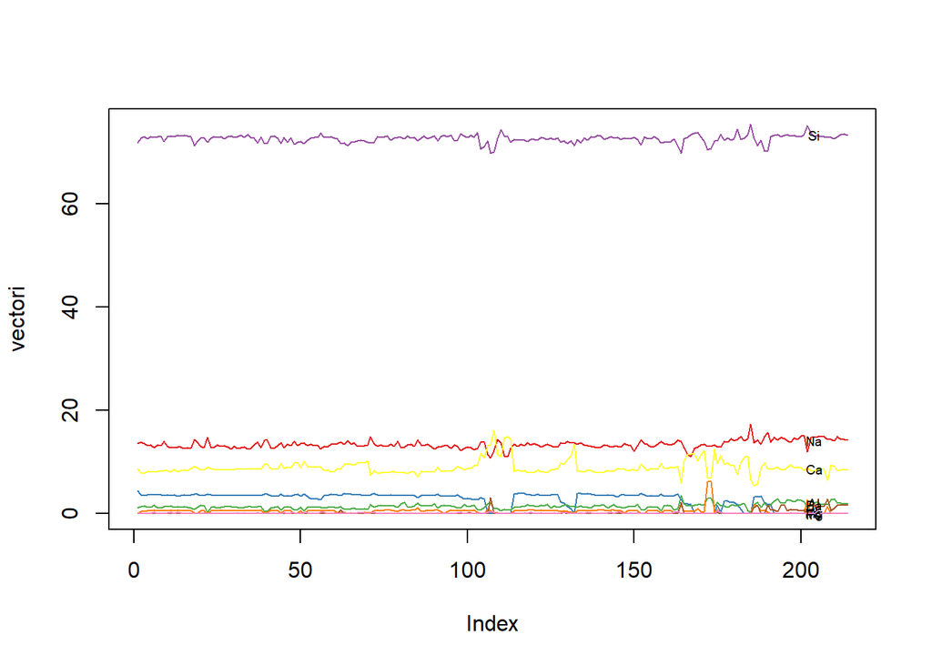

```r
library(RColorBrewer)
makeProfilePlot <- function(mylist,names)
{
  require(RColorBrewer)
  # find out how many variables we want to include
  numvariables <- length(mylist)
  # choose 'numvariables' random colours
  colours <- brewer.pal(numvariables,"Set1")
  # find out the minimum and maximum values of the variables:
  mymin <- 1e+20
  mymax <- 1e-20
  for (i in 1:numvariables)
  {
    vectori <- mylist[[i]]
    mini <- min(vectori)
    maxi <- max(vectori)
    if (mini < mymin) { mymin <- mini }
    if (maxi > mymax) { mymax <- maxi }
  }
  # plot the variables
  for (i in 1:numvariables)
  {
    vectori <- mylist[[i]]
    namei <- names[i]
    colouri <- colours[i]
    if (i == 1) { plot(vectori,col=colouri,type="l",ylim=c(mymin,mymax)) }
    else         { points(vectori, col=colouri,type="l")                                     }
    lastxval <- length(vectori)
    lastyval <- vectori[length(vectori)]
    text((lastxval-10),(lastyval),namei,col="black",cex=0.6)
  }
}

names <- c("Na","Mg","Al","Si","K","Ca","Ba","Fe")
list <- list(glass$V3,glass$V4,glass$V5,glass$V6,glass$V7,glass$V8,glass$V9,glass$V10)
makeProfilePlot(list,names)
```

From the profile plot we see that Si has a higher mean compared to other elements.

We now calculate the mean and standard deviation of each of the variables in our dataset. We also calculate the means and standarad deviations of samples having the same glass type.

```r
sapply(glass[2:10], mean)
```

```
##          V2          V3          V4          V5          V6          V7
##  1.51836542 13.40785047  2.68453271  1.44490654 72.65093458  0.49705607
##          V8          V9         V10
##  8.95696262  0.17504673  0.05700935
```

```r
sapply(glass[2:10], sd)
```

```
##          V2          V3          V4          V5          V6          V7
## 0.003036864 0.816603556 1.442407845 0.499269646 0.774545795 0.652191846
##          V8          V9         V10
## 1.423153487 0.497219261 0.097438701
```

```r
aggregate(glass[2:10],list(glass$V11),FUN=mean)
```

```
##   Group.1       V2       V3        V4       V5       V6        V7        V8
## 1       1 1.518718 13.24229 3.5524286 1.163857 72.61914 0.4474286  8.797286
## 2       2 1.518619 13.11171 3.0021053 1.408158 72.59803 0.5210526  9.073684
## 3       3 1.517964 13.43706 3.5435294 1.201176 72.40471 0.4064706  8.782941
## 4       5 1.518928 12.82769 0.7738462 2.033846 72.36615 1.4700000 10.123846
## 5       6 1.517456 14.64667 1.3055556 1.366667 73.20667 0.0000000  9.356667
## 6       7 1.517116 14.44207 0.5382759 2.122759 72.96586 0.3251724  8.491379
##            V9        V10
## 1 0.012714286 0.05700000
## 2 0.050263158 0.07973684
## 3 0.008823529 0.05705882
## 4 0.187692308 0.06076923
## 5 0.000000000 0.00000000
## 6 1.040000000 0.01344828
```

```r
aggregate(glass[2:10],list(glass$V11),FUN=sd)
```

```
##   Group.1          V2        V3        V4        V5        V6        V7
## 1       1 0.002268097 0.4993015 0.2470430 0.2731581 0.5694842 0.2148790
## 2       2 0.003802126 0.6641594 1.2156615 0.3183403 0.7245726 0.2137262
## 3       3 0.001916360 0.5068871 0.1627859 0.3474889 0.5122758 0.2298897
## 4       5 0.003345355 0.7770366 0.9991458 0.6939205 1.2823191 2.1386951
## 5       6 0.003115783 1.0840203 1.0971339 0.5718610 1.0794675 0.0000000
## 6       7 0.002545069 0.6863588 1.1176828 0.4427261 0.9402337 0.6684931
##          V8         V9        V10
## 1 0.5748066 0.08383769 0.08907496
## 2 1.9216353 0.36234044 0.10643275
## 3 0.3801112 0.03638034 0.10786361
## 4 2.1837908 0.60825096 0.15558821
## 5 1.4499483 0.00000000 0.00000000
## 6 0.9735052 0.66534094 0.02979404
```

We calculate the within-groups variance and between-groups variance and use these to get the separations achieved by all variables.

```r
calcWithinGroupsVariance <- function(variable,groupvariable)
{
  # find out how many values the group variable can take
  groupvariable2 <- as.factor(groupvariable[[1]])
  levels <- levels(groupvariable2)
  numlevels <- length(levels)
  # get the mean and standard deviation for each group:
  numtotal <- 0
  denomtotal <- 0
  for (i in 1:numlevels)
  {
    leveli <- levels[i]
    levelidata <- variable[groupvariable==leveli,]
    levelilength <- length(levelidata)
    # get the standard deviation for group i:
    sdi <- sd(levelidata)
    numi <- (levelilength - 1)*(sdi * sdi)
    denomi <- levelilength
    numtotal <- numtotal + numi
    denomtotal <- denomtotal + denomi
  }
  # calculate the within-groups variance
  Vw <- numtotal / (denomtotal - numlevels)
  return(Vw)
}
calcWithinGroupsVariance(glass[2],glass[11])
```

```
## [1] 9.092566e-06
```

```r
calcBetweenGroupsVariance <- function(variable,groupvariable)
{
  # find out how many values the group variable can take
  groupvariable2 <- as.factor(groupvariable[[1]])
  levels <- levels(groupvariable2)
  numlevels <- length(levels)
  # calculate the overall grand mean:
  grandmean <- sapply(variable,mean)
  # get the mean and standard deviation for each group:
  numtotal <- 0
  denomtotal <- 0
  for (i in 1:numlevels)
  {
    leveli <- levels[i]
    levelidata <- variable[groupvariable==leveli,]
    levelilength <- length(levelidata)
    # get the mean and standard deviation for group i:
    meani <- mean(levelidata)
    sdi <- sd(levelidata)
    numi <- levelilength * ((meani - grandmean)^2)
    denomi <- levelilength
    numtotal <- numtotal + numi
    denomtotal <- denomtotal + denomi
  }
  # calculate the between-groups variance
  Vb <- numtotal / (numlevels - 1)
  Vb <- Vb[[1]]
  return(Vb)
}
calcBetweenGroupsVariance (glass[2],glass[11])
```

```
## [1] 1.462953e-05
```

```r
calcSeparations <- function(variables,groupvariable)
{
  # find out how many variables we have
  variables <- as.data.frame(variables)
  numvariables <- length(variables)
  # find the variable names
  variablenames <- colnames(variables)
  # calculate the separation for each variable
  for (i in 1:numvariables)
  {
    variablei <- variables[i]
    variablename <- variablenames[i]
    Vw <- calcWithinGroupsVariance(variablei, groupvariable)
    Vb <- calcBetweenGroupsVariance(variablei, groupvariable)
    sep <- Vb/Vw
    print(paste("variable",variablename,"Vw=",Vw,"Vb=",Vb,"separation=",sep))
  }
}
calcSeparations(glass[2:10],glass[11])
```

```
## [1] "variable V2 Vw= 9.09256566856039e-06 Vb= 1.46295306177952e-05 separation= 1.60895517844652"
## [1] "variable V3 Vw= 0.404964286008507 Vb= 11.5609279450368 separation= 28.5480185400693"
## [1] "variable V4 Vw= 0.82721001078692 Vb= 54.2190842054697 separation= 65.5445213409488"
## [1] "variable V5 Vw= 0.137325308413137 Vb= 4.90617679618173 separation= 35.726675970184"
## [1] "variable V6 Vw= 0.575764361484578 Vb= 1.60484517906397 separation= 2.78732982869235"
## [1] "variable V7 Vw= 0.359895987045942 Vb= 3.14841600430936 separation= 8.74812756361036"
## [1] "variable V8 Vw= 1.93578249119153 Vb= 5.75203350661947 separation= 2.97142552574641"
## [1] "variable V9 Vw= 0.130709549338343 Vb= 5.09435265406698 separation= 38.9746019311885"
## [1] "variable V10 Vw= 0.00912771710636864 Vb= 0.0247441646367469 separation= 2.71088206923967"
```

The variable which gives the greatest separation between groups is V4.

To analyze the relationship between variables we look at within-groups covariance and between-groups variance.

```r
calcWithinGroupsCovariance <- function(variable1,variable2,groupvariable)
{
  # find out how many values the group variable can take
  groupvariable2 <- as.factor(groupvariable[[1]])
  levels <- levels(groupvariable2)
  numlevels <- length(levels)
  # get the covariance of variable 1 and variable 2 for each group:
  Covw <- 0
  for (i in 1:numlevels)
  {
    leveli <- levels[i]
    levelidata1 <- variable1[groupvariable==leveli,]
    levelidata2 <- variable2[groupvariable==leveli,]
    mean1 <- mean(levelidata1)
    mean2 <- mean(levelidata2)
    levelilength <- length(levelidata1)
    # get the covariance for this group:
    term1 <- 0
    for (j in 1:levelilength)
    {
      term1 <- term1 + ((levelidata1[j] - mean1)*(levelidata2[j] - mean2))
    }
    Cov_groupi <- term1 # covariance for this group
    Covw <- Covw + Cov_groupi
  }
  totallength <- nrow(variable1)
  Covw <- Covw / (totallength - numlevels)
  return(Covw)
}

calcWithinGroupsCovariance(glass[3],glass[6],glass[11])
```

```
## [1] -0.1376492
```

```r
calcBetweenGroupsCovariance <- function(variable1,variable2,groupvariable)
{
  # find out how many values the group variable can take
  groupvariable2 <- as.factor(groupvariable[[1]])
  levels <- levels(groupvariable2)
  numlevels <- length(levels)
  # calculate the grand means
  variable1mean <- sapply(variable1,mean)
  variable2mean <- sapply(variable2,mean)
  # calculate the between-groups covariance
  Covb <- 0
  for (i in 1:numlevels)
  {
    leveli <- levels[i]
    levelidata1 <- variable1[groupvariable==leveli,]
    levelidata2 <- variable2[groupvariable==leveli,]
    mean1 <- mean(levelidata1)
    mean2 <- mean(levelidata2)
    levelilength <- length(levelidata1)
    term1 <- (mean1 - variable1mean)*(mean2 - variable2mean)*(levelilength)
    Covb <- Covb + term1
  }
  Covb <- Covb / (numlevels - 1)
  Covb <- Covb[[1]]
  return(Covb)
}

calcBetweenGroupsCovariance(glass[3],glass[6],glass[11])
```

```
## [1] 3.845254
```

The within-groups covariance between V3 AND V6 is negative(-0.1376492) so for samples from the same group,samples with high mean value of V3 tend to have low mean value of V6.The between-groups covariance between V3 and V6 is positive(3.845254) so groups with high mean value of V3 tend to have high mean value of V6.

Calculating the correlation coefficient for each pair of variables:

```r
cor(glass[2:10])
```

```
##                V2          V3           V4          V5          V6           V7
## V2   1.0000000000 -0.19188538 -0.122274039 -0.40732603 -0.54205220 -0.289832711
## V3  -0.1918853790  1.00000000 -0.273731961  0.15679367 -0.06980881 -0.266086504
## V4  -0.1222740393 -0.27373196  1.000000000 -0.48179851 -0.16592672  0.005395667
## V5  -0.4073260341  0.15679367 -0.481798509  1.00000000 -0.00552372  0.325958446
## V6  -0.5420521997 -0.06980881 -0.165926723 -0.00552372  1.00000000 -0.193330854
## V7  -0.2898327111 -0.26608650  0.005395667  0.32595845 -0.19333085  1.000000000
## V8   0.8104026963 -0.27544249 -0.443750026 -0.25959201 -0.20873215 -0.317836155
## V9  -0.0003860189  0.32660288 -0.492262118  0.47940390 -0.10215131 -0.042618059
## V10  0.1430096093 -0.24134641  0.083059529 -0.07440215 -0.09420073 -0.007719049
##             V8            V9          V10
## V2   0.8104027 -0.0003860189  0.143009609
## V3  -0.2754425  0.3266028795 -0.241346411
## V4  -0.4437500 -0.4922621178  0.083059529
## V5  -0.2595920  0.4794039017 -0.074402151
## V6  -0.2087322 -0.1021513105 -0.094200731
## V7  -0.3178362 -0.0426180594 -0.007719049
## V8   1.0000000 -0.1128409671  0.124968219
## V9  -0.1128410  1.0000000000 -0.058691755
## V10  0.1249682 -0.0586917554  1.000000000
```

Now we carry out the principal component analysis. To do PCA we first standardise the variables so that all variables have variance 1 and mean 0.

```r
standardisedconcentration <- as.data.frame(scale(glass[2:10]))
sapply(standardisedconcentration,mean)
```

```
##            V2            V3            V4            V5            V6
## -2.869988e-14  7.245916e-18 -9.197378e-17  1.174490e-16  9.353384e-16
##            V7            V8            V9           V10
## -3.404040e-17 -3.173510e-16  3.287666e-17 -6.287917e-17
```

```r
sapply(standardisedconcentration, sd)
```

```
##  V2  V3  V4  V5  V6  V7  V8  V9 V10
##   1   1   1   1   1   1   1   1   1
```

```r
glass.pca <- prcomp(standardisedconcentration)
summary(glass.pca)
```

```
## Importance of components:
##                          PC1    PC2    PC3    PC4    PC5     PC6    PC7     PC8
## Standard deviation     1.585 1.4318 1.1853 1.0760 0.9560 0.72639 0.6074 0.25269
## Proportion of Variance 0.279 0.2278 0.1561 0.1286 0.1016 0.05863 0.0410 0.00709
## Cumulative Proportion  0.279 0.5068 0.6629 0.7915 0.8931 0.95173 0.9927 0.99982
##                            PC9
## Standard deviation     0.04011
## Proportion of Variance 0.00018
## Cumulative Proportion  1.00000
```

```r
glass.pca$sdev
```

```
## [1] 1.58466518 1.43180731 1.18526115 1.07604017 0.95603465 0.72638502 0.60741950
## [8] 0.25269141 0.04011007
```

```r
sum((glass.pca$sdev)^2)
```

```
## [1] 9
```

Total variance is 9 which is equal to the number of standardised variables.  
To decide how many components to retain,we plot the screeplot.

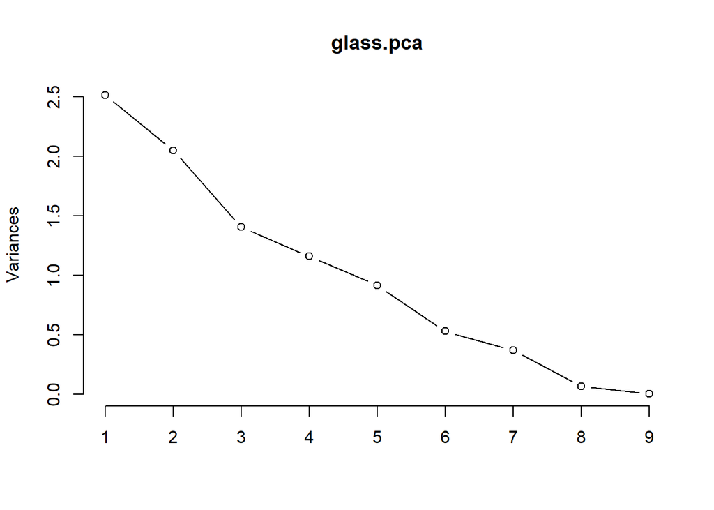

```r
screeplot(glass.pca,type = "lines")
```

We can also decide how many components to retain using Kaiser’s criterion.

```r
(glass.pca$sdev)^2
```

```
## [1] 2.511163726 2.050072185 1.404843994 1.157862446 0.914002247 0.527635193
## [7] 0.368958443 0.063852948 0.001608818
```

As the variance of components 1,2,3 and 4(2.511163726 2.050072185 1.404843994 and 1.157862446 respectively) is greater than 1,we retain these components.  
We can calculate the loadings of each principal component and the values of the principal component for each sample in our data.

```r
glass.pca$rotation[]
```

```
##            PC1         PC2           PC3         PC4          PC5         PC6
## V2  -0.5451766  0.28568318  0.0869108293  0.14738099 -0.073542700  0.11528772
## V3   0.2581256  0.27035007 -0.3849196197  0.49124204  0.153683304 -0.55811757
## V4  -0.1108810 -0.59355826  0.0084179590  0.37878577  0.123509124  0.30818598
## V5   0.4287086  0.29521154  0.3292371183 -0.13750592  0.014108879 -0.01885731
## V6   0.2288364 -0.15509891 -0.4587088382 -0.65253771  0.008500117  0.08609797
## V7   0.2193440 -0.15397013  0.6625741197 -0.03853544 -0.307039842 -0.24363237
## V8  -0.4923061  0.34537980 -0.0009847321 -0.27644322 -0.188187742 -0.14866937
## V9   0.2503751  0.48470218  0.0740547309  0.13317545  0.251334261  0.65721884
## V10 -0.1858415 -0.06203879  0.2844505524 -0.23049202  0.873264047 -0.24304431
##             PC7         PC8         PC9
## V2  -0.08186724 -0.75221590 -0.02573194
## V3  -0.14858006 -0.12769315  0.31193718
## V4   0.20604537 -0.07689061  0.57727335
## V5   0.69923557 -0.27444105  0.19222686
## V6  -0.21606658 -0.37992298  0.29807321
## V7  -0.50412141 -0.10981168  0.26050863
## V8   0.09913463  0.39870468  0.57932321
## V9  -0.35178255  0.14493235  0.19822820
## V10 -0.07372136 -0.01627141  0.01466944
```

```r
glass.pca$x[]
```

```
##                 PC1         PC2          PC3           PC4         PC5
##   [1,] -1.148446843 -0.52824907 -0.371225255  1.7248568105 -0.25134650
##   [2,]  0.572794160 -0.75801049 -0.555405924  0.7584539597 -0.25646936
##   [3,]  0.937960515 -0.92766091 -0.553609408  0.2057718428 -0.23695030
##   [4,]  0.141750924 -0.95942790 -0.116850709  0.4147515674 -0.47518475
##   [5,]  0.350271021 -1.08869658 -0.483944005  0.0689406529 -0.43107920
##   [6,]  0.289587596 -1.32091046  0.866646619 -0.9256271150  1.81041578
##   [7,]  0.252080399 -1.11353870 -0.539373202  0.0801402072 -0.45745086
##   [8,]  0.120018063 -1.21898810 -0.623280854 -0.1157506818 -0.49341814
##   [9,]  0.020767338 -0.32117955 -0.108804570  1.3684635985 -0.37463504
##  [10,]  0.002346727 -1.06332030  0.120572324 -0.3751414534  0.44843827
##  [11,]  0.381620164 -1.37690564  0.687911388 -1.1548529059  1.59526869
##  [12,]  0.013322630 -1.10213499 -0.144462275 -0.2405245805 -0.60944640
##  [13,]  0.308999887 -1.41971148  0.484926709 -1.0744886211  1.61068277
##  [14,] -0.156154882 -1.23303717  0.139379929 -0.7700931118  0.97473109
```

[output cut: 415 more lines]

We analyze the first five principal components:

```r
glass.pca$rotation[,1]
```

```
##         V2         V3         V4         V5         V6         V7         V8
## -0.5451766  0.2581256 -0.1108810  0.4287086  0.2288364  0.2193440 -0.4923061
##         V9        V10
##  0.2503751 -0.1858415
```

The first principal component has highest(in absolute value) loadings for V2(-0.5451766),V8(-0.4923061),V5( 0.4287086),V3(0.2581256) and V9(0.2503751).The loadings of V3,V5,V9 are positive and V2,V8 are negative.So the first component represents a contrast between the concentrations of V3,V5,V9 and the concentrations of V2,V8.

```r
glass.pca$rotation[,2]
```

```
##          V2          V3          V4          V5          V6          V7
##  0.28568318  0.27035007 -0.59355826  0.29521154 -0.15509891 -0.15397013
##          V8          V9         V10
##  0.34537980  0.48470218 -0.06203879
```

The second principal component has highest(in absolute value) loadings for V4(-0.59355826), V9(0.48470218), V8(0.34537980), V5(0.29521154), V2(0.28568318).The loadings of V9,V8,V5,V2 are positive and V4 is negative.So the second component represents a contrast between the concentrations of V9,V8,V5,V2 and the concentration of V4.

```r
glass.pca$rotation[,3]
```

```
##            V2            V3            V4            V5            V6
##  0.0869108293 -0.3849196197  0.0084179590  0.3292371183 -0.4587088382
##            V7            V8            V9           V10
##  0.6625741197 -0.0009847321  0.0740547309  0.2844505524
```

The third principal component has highest(in absolute value) loadings for V7(0.6625741197), V6(-0.4587088382), V3(-0.3849196197), V5(0.3292371183), V10(0.2844505524).The loadings of V7,V5,V10 are positive and V6,V3 are negative.So the third component represents a contrast between the concentrations of V7,V5,V10 and the concentrations of V6,V3.

```r
glass.pca$rotation[,4]
```

```
##          V2          V3          V4          V5          V6          V7
##  0.14738099  0.49124204  0.37878577 -0.13750592 -0.65253771 -0.03853544
##          V8          V9         V10
## -0.27644322  0.13317545 -0.23049202
```

The fourth principal component has highest(in absolute value) loadings for V6(-0.65253771), V3(0.49124204), V4(0.37878577), V8(-0.27644322), V10(-0.23049202).The loadings of V3,V4 are positive and V6,V8,V10 are negative.So the fourth component represents a contrast between the concentrations of V3,V4 and the concentrations of V6,V8,10.

```r
glass.pca$rotation[,5]
```

```
##           V2           V3           V4           V5           V6           V7
## -0.073542700  0.153683304  0.123509124  0.014108879  0.008500117 -0.307039842
##           V8           V9          V10
## -0.188187742  0.251334261  0.873264047
```

We now make scatterplots to analyze our data further.

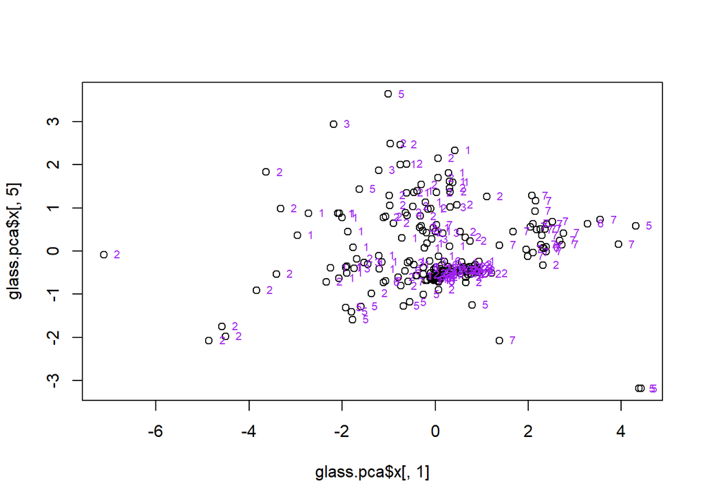

```r
plot(glass.pca$x[,1],glass.pca$x[,5])
text(glass.pca$x[,1],glass.pca$x[,5],glass$V11,cex = 0.65,pos = 4, col = "purple")
```

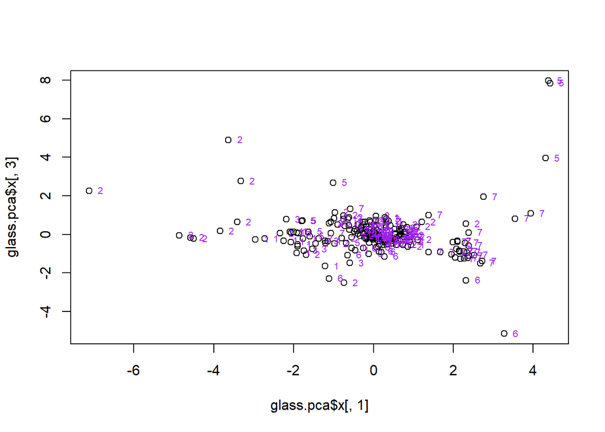

```r
plot(glass.pca$x[,1],glass.pca$x[,3])
text(glass.pca$x[,1],glass.pca$x[,3],glass$V11,cex = 0.65,pos = 4, col = "purple")
```

Scatterplot 2 shows first principal component on the x-axis and third principal component on the y-axis.We can see from scatterplot 2 that samples with glass type 7 have higher values of first principal component than samples with any other glass type. Also samples with glass type 6 have lower values of third principal component than samples with any other glass type. So the first principal component separates samples of glass type 7 from samples of other types and third component separates samples of glass type 6 from samples of other types.

Therefore first,third and fifth principal components are useful for distinguishing between samples of different glass types.

We check if this classification makes sense by calculating the means of the standardised concentration variables in each glass type.

```r
aggregate(standardisedconcentration,list(glass$V11),FUN=mean)
```

```
##   Group.1          V2         V3         V4          V5          V6          V7
## 1       1  0.11619394 -0.2027480  0.6016993 -0.56292106 -0.04104563 -0.07609341
## 2       2  0.08335312 -0.3626484  0.2201683 -0.07360481 -0.06830876  0.03679371
## 3       3 -0.13233756  0.0357681  0.5955297 -0.48817322 -0.31790076 -0.13889393
## 4       5  0.18514882 -0.7104526 -1.3246507  1.17960228 -0.36767449  1.49180633
## 5       6 -0.29960679  1.5170350 -0.9560244 -0.15670866  0.71749416 -0.76213169
## 6       7 -0.41134992  1.2664879 -1.4879681  1.35768734  0.40659635 -0.26354770
##            V8         V9           V10
## 1 -0.11219935 -0.3264806 -0.0000959146
## 2  0.08201617 -0.2509629  0.2332491727
## 3 -0.12227876 -0.3343056  0.0005077832
## 4  0.81992810  0.0254326  0.0385871830
## 5  0.28085801 -0.3520514 -0.5850790848
## 6 -0.32714905  1.7395812 -0.4470612770
```

For glass type 6,we see that mean values of V7(-0.76213169), V5(-0.15670866), V10(-0.5850790848) are very low compared to mean values of V6(0.71749416), V3(1.5170350). So it makes sense that principal component 3 is a contrast between the concentrations of V7,V5,V10 and the concentrations of V6,V3 and separates glass type 6 from other glass types.

For glass type 7,we see that mean values of V3(1.2664879), V5(1.35768734), V9(1.7395812) are very high compared to mean values of V2(-0.41134992), V8(-0.32714905). So it makes sense that principal component is a contrast between the concentrations of V3,V5,V9 and the concentrations of V2,V8 and separates glass type 7 from other glass types.